# PCA-Barrios

Marc Hurtado

2024-04-24

# 1 PCA-Barrios

## 1.1 Carga de los datos

En primer lugar, cargamos los datos del dataset de barrios y eliminamos las columnas que no son necesarias para el análisis, estas filas son:

- barrio: Nombres del barrio, ya que están representados como índices.
- geo_shape: Información geográfica del barrio, no aporta información relevante.
- X: Columna de índices que no aporta información relevante.

```r
#Obtenemos los datos del dataset completo de barrios
dataBarrios <- read.csv("../data/info_general_barrio_final.csv", sep = ",")

#Reemplazamos los valores NA por 0
dataBarrios[is.na(dataBarrios)] <- 0

#Asignamos los nombres de los barrios como índices
rownames(dataBarrios) <- dataBarrios$barrio

#Eliminamos las columnas que no son necesarias para el análisis
dataBarrios2 <- subset(dataBarrios, select = -c(barrio, geo_shape, X))
```

## 1.2 Análisis de Componentes Principales (PCA)

Realizamos un análisis de componentes principales (PCA), mediante la libreria FactoMineR para reducir la dimensionalidad de los datos y visualizar la estructura de los barrios en un espacio de menor dimensión.

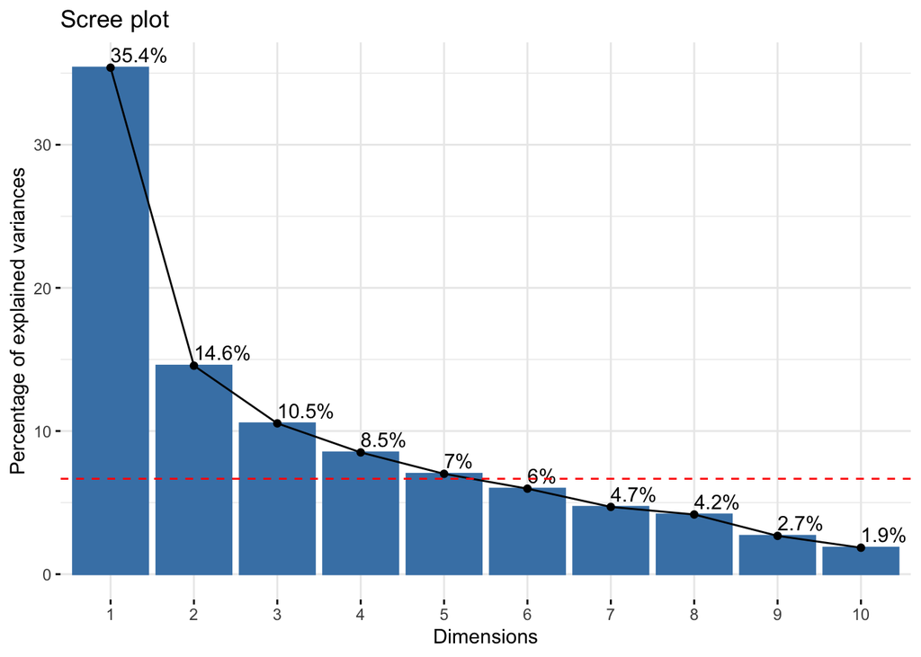

```r
#Creación del PCA
res.pca = PCA(dataBarrios2, scale.unit = TRUE, ncp = Inf, graph = FALSE, quanti.sup =  c("X0_15_años", "X16_64_años", "X65_o_más"), quali.sup = "distrito")

#Obtenemos los valores propios
eig.val <- get_eigenvalue(res.pca)

#Mostramos el gráfico de los valores propios, que nos ayudara a seleccionar las componentes
VPmedio = 100 * (1/nrow(eig.val))
fviz_eig(res.pca, addlabels = TRUE) +
  geom_hline(yintercept=VPmedio, linetype=2, color="red")
```

```r
K = 4
kable(eig.val)
```

|  | eigenvalue | variance.percent | cumulative.variance.percent |
| --- | --- | --- | --- |
| Dim.1 | 5.3074905 | 35.3832698 | 35.38327 |
| Dim.2 | 2.1848997 | 14.5659977 | 49.94927 |
| Dim.3 | 1.5803769 | 10.5358461 | 60.48511 |
| Dim.4 | 1.2759011 | 8.5060076 | 68.99112 |
| Dim.5 | 1.0515780 | 7.0105198 | 76.00164 |
| Dim.6 | 0.8962128 | 5.9747522 | 81.97639 |
| Dim.7 | 0.7050651 | 4.7004338 | 86.67683 |
| Dim.8 | 0.6256202 | 4.1708015 | 90.84763 |
| Dim.9 | 0.4016170 | 2.6774465 | 93.52507 |
| Dim.10 | 0.2776763 | 1.8511750 | 95.37625 |
| Dim.11 | 0.2383501 | 1.5890005 | 96.96525 |
| Dim.12 | 0.1883422 | 1.2556150 | 98.22087 |
| Dim.13 | 0.1399740 | 0.9331598 | 99.15403 |
| Dim.14 | 0.1100098 | 0.7333990 | 99.88742 |
| Dim.15 | 0.0168864 | 0.1125757 | 100.00000 |

Ahora, una vez determinado el número de componnetes para el análisis, realizamos el PCA con K = 4.

```r
res.pca = PCA(dataBarrios2, scale.unit = TRUE, ncp = K, graph = FALSE, quanti.sup = c("X0_15_años", "X16_64_años", "X65_o_más"), quali.sup = "distrito")
```

## 1.3 Validación del PCA

### 1.3.1 Estadístico T2 de Hotelling

Para determinar, que tan bien se ajusta el modelo PCA a los datos, calculamos el estadístico T2 de Hotelling, que nos permite identificar las observaciones anómalas en el conjunto de datos. Para esto debemos obtener los Scores y obtener las contribuciones.

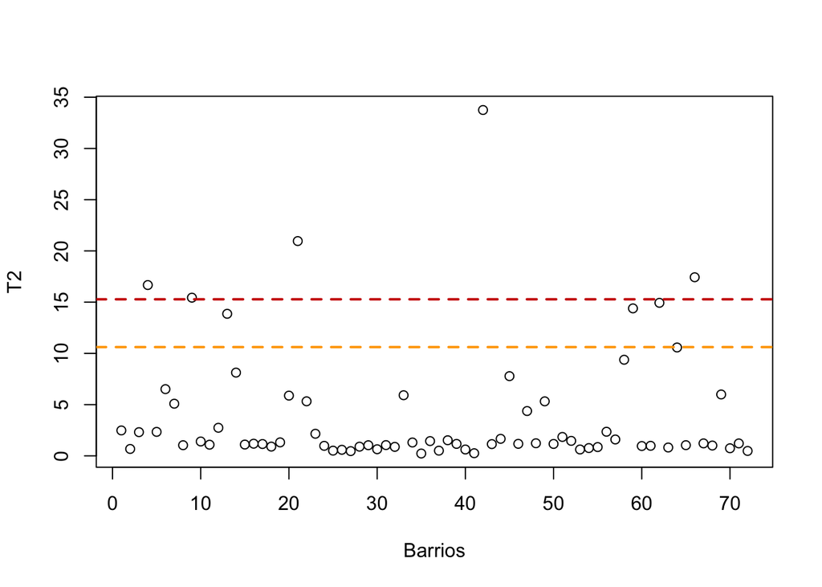

```r
misScores = res.pca$ind$coord[,1:K]
miT2 = colSums(t(misScores**2)/eig.val[1:K,1])

I = nrow(dataBarrios)

F95 = K*(I**2 - 1)/(I*(I - K)) * qf(0.95, K, I-K)
F99 = K*(I**2 - 1)/(I*(I - K)) * qf(0.99, K, I-K) #15.2

plot(1:length(miT2), miT2, type = "p", xlab = "Barrios", ylab = "T2")
abline(h = F95, col = "orange", lty = 2, lwd = 2)
abline(h = F99, col = "red3", lty = 2, lwd = 2)
```

```r
anomalos=which(miT2>F99)

kable(miT2[anomalos])
```

|  | x |
| --- | --- |
| BENICALAP | 16.67019 |
| CABANYAL-CANYAMELAR | 15.43756 |
| EL GRAU | 20.96060 |
| LA PUNTA | 33.75097 |
| SANT PAU | 17.43003 |

Para estudiar que variables causan que estos barrios sean anómalos, calculamos las contribuciones de las variables a las observaciones anómalas. Para esto, empleamos la función `contribT2` que calcula las contribuciones de las variables a las observaciones anómalas.

```r
contribT2 = function (X, scores, loadings, eigenval, observ, cutoff = 2) {
  # X is data matrix and must be centered (or centered and scaled if data were scaled)
  misScoresNorm = t(t(scores**2) / eigenval)
  misContrib = NULL
  for (oo in observ) {
    print(rownames(misScores)[oo])
    print(misScores[oo,])
    misPCs = which(as.numeric(misScoresNorm[oo,]) > cutoff)
    lacontri = sapply(misPCs, function (cc) (misScores[oo,cc]/eigenval[cc])*loadings[,cc]*X[oo,])
    lacontri = rowSums((1*(sign(lacontri) == 1))*lacontri)
    misContrib = cbind(misContrib, lacontri)
  }
  colnames(misContrib) = rownames(misScoresNorm[observ,])
  return(misContrib)
}
```

Para aplicar la función `contribT2`, primero debemos centrar y escalar los datos y calcular los loadings a partir de las coordenadas de las variables. Obtenemos los Loadings a partir de las coordenadas de las variables, ya que la librería FactoMineR nos devuelve los loadings ponderados por la importancia de cada componente principal.

```r
#Obtenemos la matriz de datos centrada y escalada
barriosCE = subset(dataBarrios2, select=-c(X0_15_años, X16_64_años, X65_o_más, distrito))
barriosCE = scale(barriosCE, center = TRUE, scale = TRUE)
X = as.matrix(barriosCE)

# Calculamos los loadings a partir de las coordenadas de las variables
misLoadings = sweep(res.pca$var$coord, 2, sqrt(res.pca$eig[1:K,1]), FUN="/")

# Calculamos las contribuciones
mycontrisT2 = contribT2(X = X, scores = misScores, loadings = misLoadings,
                        eigenval = eig.val[1:K,1], observ = which(miT2>F99),
                        cutoff = 2)
```

```
## [1] "BENICALAP"
##      Dim.1      Dim.2      Dim.3      Dim.4
##  6.6909384 -2.5538440  2.7489608  0.7731236
## [1] "CABANYAL-CANYAMELAR"
##    Dim.1    Dim.2    Dim.3    Dim.4
## 6.072779 1.377084 3.159742 1.289750
## [1] "EL GRAU"
##      Dim.1      Dim.2      Dim.3      Dim.4
##  2.6562984 -0.1202215 -2.6953854  4.3787658
## [1] "LA PUNTA"
##     Dim.1     Dim.2     Dim.3     Dim.4
##  3.439256 -1.361490 -3.612425  5.348031
## [1] "SANT PAU"
##      Dim.1      Dim.2      Dim.3      Dim.4
##  6.8097732  0.2482618 -3.4669423 -1.1623791
```